# Лабораторная работа №12

Администрирование сетевых подсистем

Иванов Сергей Владимирович, НПИбд-01-23

Российский университет дружбы народов, Москва, Россия

10 ноября 2025

# Цель работы

Получение навыков по управлению системным временем и настройке синхронизации времени.

# Задание

1. Изучите команды по настройке параметров времени
2. Настройте сервер в качестве сервера синхронизации времени для локальной сети
3. Напишите скрипты для Vagrant, фиксирующие действия по установке и настройке NTP-сервера и клиента

# Выполнение лабораторной работы

## Настройка параметров времени

На сервере и клиенте посмотрим параметры настройки даты и времени: (рис. 1, 2).

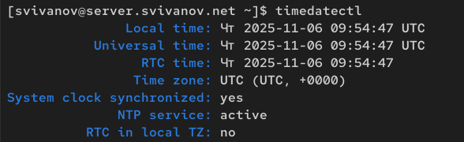

Настройки даты и времени на сервере

## Настройка параметров времени

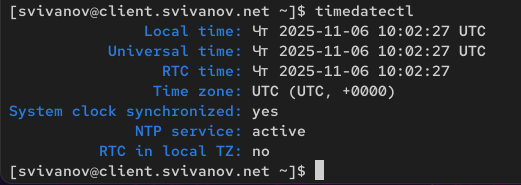

Настройки даты и времени на клиенте

## Настройка параметров времени

Поэкспериментируем с параметрами этой команды. (рис. 3)

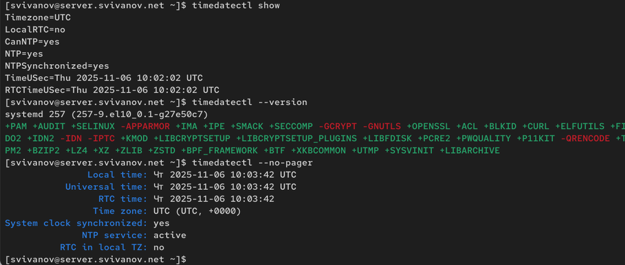

Параметры команды

## Настройка параметров времени

На сервере и клиенте посмотрим текущее системное время (рис. 4)

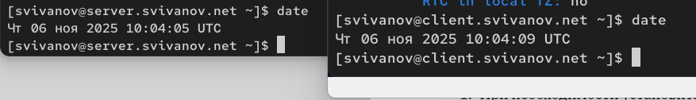

Просмотр системного времени

## Настройка параметров времени

Поэкспериментируем с параметрами этой команды. (рис. 5)

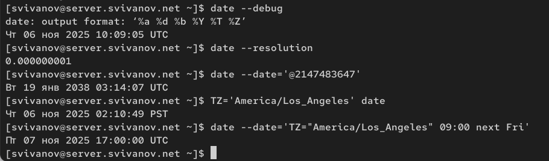

Параметры date

## Настройка параметров времени

На сервере и клиенте посмотрим аппаратное время: (рис. 6)

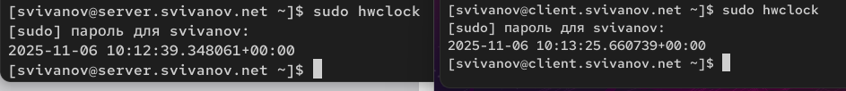

Аппаратное время

## Управление синхронизацией времени

Проверим источники времени на клиенте и на сервере: (рис. 7)

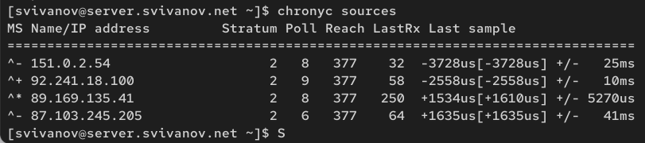

Проверка источников времени

## Управление синхронизацией времени

Клиент синхронизирован с источником vigil.intelfx.name. (рис. 8)

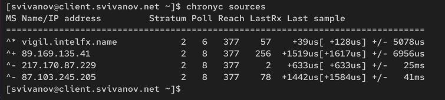

Проверка источников времени

## Управление синхронизацией времени

На сервере откроем на редактирование файл /etc/chrony.conf и добавим строку: (рис. 9)

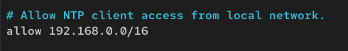

Редактирование chrony.conf

## Управление синхронизацией времени

На сервере перезапустим службу chronyd: systemctl restart chronyd (рис. 10)

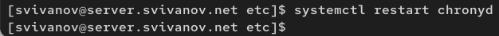

Перезапуск службы

## Управление синхронизацией времени

Настроим межсетевой экран на сервере: (рис. 11)

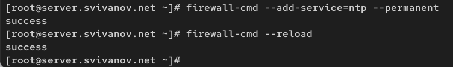

Настройка firewall

## Управление синхронизацией времени

На клиенте откроем файл /etc/chrony.conf и добавим строку: (рис. 12)

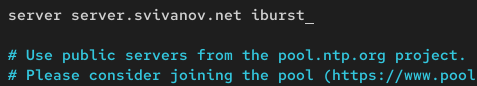

Редактирование chrony.conf

## Управление синхронизацией времени

На клиенте перезапустим службу chronyd: (рис. 13)

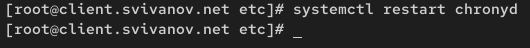

Перезапуск службы

## Управление синхронизацией времени

Проверим источники времени на клиенте и на сервере: (рис. 14)

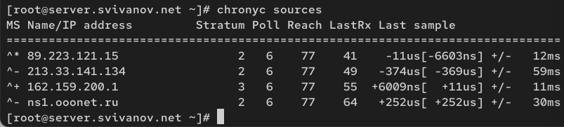

Проверка источников времени

## Управление синхронизацией времени

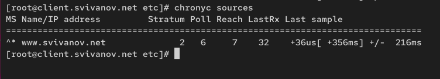

Проверка источников времени

## Управление синхронизацией времени

Посмотрим подробную информацию о синхронизации. (рис. 16)

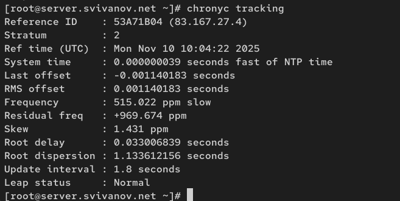

Подробная информация о синхронизации

## Управление синхронизацией времени

Посмотрим информацию на клиенте. (рис. 17)

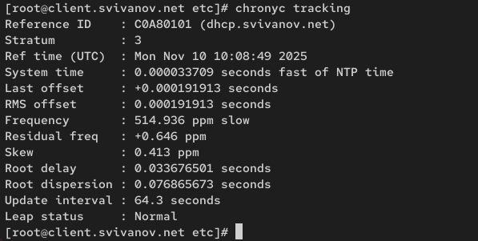

Подробная информация о синхронизации

## Внесение изменений в настройки внутреннего окружения виртуальных машин

На машине server перейдем в каталог для внесения изменений, создадим в нём каталог ntp, в который поместим конфигурационные файлы: (рис. 18)

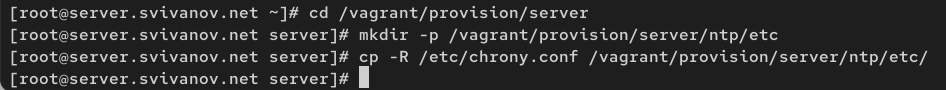

Создание каталогов и копирование конф.файла

## Внесение изменений в настройки внутреннего окружения виртуальных машин

В каталоге /vagrant/provision/server создадим скрипт ntp.sh: (рис. 19)

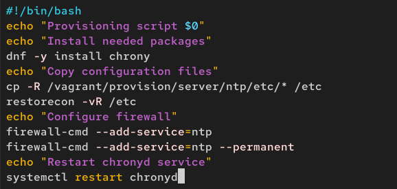

Создание скрипта

## Внесение изменений в настройки внутреннего окружения виртуальных машин

На машине client перейдем в каталог для внесения изменений, создадим в нём каталог ntp, в который поместим конфигурационные файлы: (рис. 20)

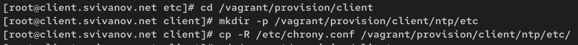

Создание каталогов и копирование конф.файла

## Внесение изменений в настройки внутреннего окружения виртуальных машин

В каталоге /vagrant/provision/client создадим скрипт ntp.sh: (рис. 21)

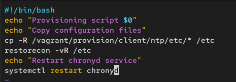

Создание скрипта

## Внесение изменений в настройки внутреннего окружения виртуальных машин

Для отработки скриптов во время загрузки виртуальных машин server и client в конфигурационном файле Vagrantfile необходимо добавить: (рис. 22, 23)

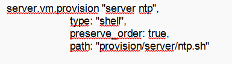

Редактирование Vagrantfile

## Внесение изменений в настройки внутреннего окружения виртуальных машин

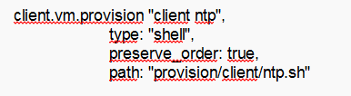

Редактирование Vagrantfile

## Вывод

В ходе выполнения лабораторной работы мы получили навыки по управлению системным временем и настройке синхронизации времени.